# Neural Network Model

### Load dataset

For this model, we will use the following training and testing datasets:

- `prediction_dataset.csv`: For prediction purposes
- `regression_dataset.csv`: For training and regression purposes
- `vnm_.csv`: For constraints purposes

All data sets have been cleaned and contain no missing values.

```r
# Regression Dataset
regression_data <- read.csv(file.path(data_dir, "training_data/regression_dataset.csv"))

# Prediction Dataset
prediction_data <- read.csv(file.path(data_dir, "training_data/prediction_dataset.csv"))

# National GDP totals used to constrain the regression fit
constrained_data <- read.csv(file.path(data_dir, "_vnm_indicators/vnm_level0_gdp.csv"))

# Provincial GRDP per-capita targets used to calibrate 2025 level-2 predictions
provincial_grdp_data <- read.csv(file.path(data_dir,
  "_vnm_indicators/vnm_GRDPpc.csv"),
  check.names = FALSE
)

# Provincial population totals (thousands) used as the aggregation constraint
provincial_population_data <- read.csv(file.path(data_dir,
  "_vnm_indicators/vnm_population.csv"),
  check.names = FALSE
)

# Provincial population data are in thousands; convert to persons.
regression_data$population <- regression_data$population * 1000
provincial_population_data[, as.character(2020:2025)] <-
  provincial_population_data[, as.character(2020:2025)] * 1000
```

### Splitting the Training and Testing Sets

This setup performs the following tasks:

- Splits the data into a training set (2020–2024) and a holdout test set (2025).
- Selects `mean_radiance`, `population`, and `pixel_count` as the predictor variables.
- Standardizes the features in both the training and testing sets using the means and standard deviations calculated from the training data.
- Calculates the temporal extrapolation weights based on the training years

The temporal extrapolation weights is calculated as
$$w_t = \frac{1}{T}
+ \frac{(2025-\bar{t})(t-\bar{t})}
{\sum_{j=1}^{T}(t_j-\bar{t})^2}.$$

where

- $T = 5$: number of training years
- $t$: individual training years
- $\bar{t}$: mean training years

```r
model_data <- prepare_model_setup(regression_data)

X_train <- model_data$X_train
y_train <- model_data$y_train
X_test  <- model_data$X_test
y_test  <- model_data$y_test
temporal_weights = model_data$temporal_weights
training_data = model_data$training_data
holdout_data = model_data$holdout_data
training_years = model_data$training_years
holdout_year = model_data$holdout_year
y_train_raw = model_data$y_train_raw
y_test_raw = model_data$y_test_raw
feature_columns = model_data$feature_columns
feature_means = model_data$feature_means
feature_sds = model_data$feature_sds
response_mean = model_data$response_mean
response_sd = model_data$response_sd
```

### Prepare OLS references

Ordinary Least Squares (OLS) is used as a baseline reference model to evaluate predictions on both the training and holdout sets (2025). It also provides baseline performance metrics, including $R^2$ and RMSE, for comparison with more advanced models.

```r
ols_comparison <- fit_ols_comparison(model_data)

ols_coefficients <- ols_comparison$coefficients
ols_training_predictions <- ols_comparison$training
ols_holdout_predictions <- ols_comparison$holdout
ols_metrics <- ols_comparison$metrics
ols_training_predictions <- ols_comparison$training$predicted
ols_holdout_predictions <- ols_comparison$holdout$predicted
```

### Preliminaries

Supposed:

- $y \in \mathbb{R}^n$: observed outcome vector. That is, `grdp_per_capita`.
- $x_i \in \mathbb{R}^3$: standardized explanatory variables for observation $i$: `mean_radiance`, `population`, and `pixel_count`.
- $\alpha_t \in \mathbb{R}$: year-specific intercept for year $t$.
- $P_i \in \mathbb{R}$: `population` for observation $i$
- $\beta \in \mathbb{R}^3$: shared coefficients for the explanatory variables.
- $a_t \in \mathbb{R}$: specified national GDP total for year $t$.

### Neural Network architecture

The neural network uses a single hidden layer with a linear output:

$$\hat{y}_{it} =
f_{\mathrm{NN}}\left(x_{it},\,\alpha_{2021,t},\ldots,\alpha_{2024,t}\right).$$

```r
fit_neural_network <- function(
  x,
  y,
  size,
  decay,
  seed,
  maxit = 3000
) {
  set.seed(seed)
  fit <- nnet(
    x = x,
    y = matrix(y, ncol = 1),
    size = size,
    decay = decay,
    linout = TRUE,
    maxit = maxit,
    MaxNWts = 5000,
    rang = 0.1,
    trace = FALSE
  )
  if (fit$convergence != 0) {
    stop(sprintf(
      "Neural network did not converge (size=%d, decay=%g, seed=%d).",
      size,
      decay,
      seed
    ))
  }
  fit
}

make_prediction <- function(model, newdata) {
  as.vector(predict(model, newdata = newdata)) * response_sd +
    response_mean
}
```

#### Hidden units and decay rate

```r
hidden_units_grid <- seq(1, 14)
decay_grid <- c(0, 10^seq(-5, 0))
nn_grid <- lapply(hidden_units_grid, \(h) {
  lapply(decay_grid, \(d) c(h, d))
}) |> unlist(recursive = FALSE)
```

The model is fitted using the 2020–2024 training data with the shared standardized response and design matrix.

```r
# Initialize storage for model results.

# training_predictions: predictions on training data
training_predictions <- matrix(
  NA_real_,
  nrow = nrow(training_data),
  ncol = length(nn_grid)
)

# holdout_predictions: predictions on testing data
holdout_predictions <- matrix(
  NA_real_,
  nrow = nrow(holdout_data),
  ncol = length(nn_grid)
)
```

```r
for (grid_index in seq_along(nn_grid)) {
  model <- fit_neural_network(
    x = X_train,
    y = y_train,
    size = nn_grid[[grid_index]][1],
    decay = nn_grid[[grid_index]][2],
    seed = 401 + grid_index
  )

  # Training predictions
  training_predictions[, grid_index] <- make_prediction(model, X_train)

  # Holdout predictions
  holdout_predictions[, grid_index] <- make_prediction(model, X_test)
}
```

### Model Evaluation and Hyperparameter Selection

For each data split, the mean and total sum of squares (SST) are calculated using the observed GRDP-per-capita values within that split. We evaluate model performance using the following metrics.

The coefficient of determination ($R^2$) is calculated for each model as

$$R^2
= 1-\frac{\sum_{i=1}^{n}(y_i-\hat y_i)^2}{\mathrm{SST}},$$

where

$$\bar y = \frac{1}{n}\sum_{i=1}^{n} y_i,
\qquad
\mathrm{SST} = \sum_{i=1}^{n}(y_i-\bar y)^2.$$

We also calculate the root mean squared error (RMSE), expressed in the original GRDP-per-capita units, as

$$\mathrm{RMSE}
=\sqrt{\frac{1}{n}\sum_{i=1}^{n}(y_i-\hat y_i)^2}.$$

```r
# Prepare diagnostics.
training_diagnostics <- lapply(seq_along(nn_grid), function(grid_index) {
  prepare_model_diagnostics(
    data = training_data,
    fitted = training_predictions[, grid_index],
    model_name = "Neural Network Model",
  )
})

holdout_diagnostics <- lapply(seq_along(nn_grid), function(grid_index) {
  prepare_model_diagnostics(
    data = holdout_data,
    fitted = holdout_predictions[, grid_index],
    model_name = "Neural Network Model",
  )
})

nn_results <- data.frame(
  size = sapply(nn_grid, `[`, 1),
  decay = sapply(nn_grid, `[`, 2),

  # Training diagnostics
  training_RMSE = sapply(training_diagnostics, function(x) {
    x$metrics$RMSE
  }),
  training_R_squared = sapply(training_diagnostics, function(x) {
    x$metrics$R_squared
  }),

  # Holdout diagnostics
  holdout_RMSE = sapply(holdout_diagnostics, function(x) {
    x$metrics$RMSE
  }),
  holdout_R_squared = sapply(holdout_diagnostics, function(x) {
    x$metrics$R_squared
  })
)

# Save
write.csv(
  nn_results,
  file.path(data_output_dir, ... =
  "nn_grid_diagnostic_metrics.csv"),
  row.names = FALSE
)
```

We select the optimal number of hidden neurons and decay rates from the candidate grid based on the holdout performance, aiming to minimize RMSE and maximize $R^2$.

```r
# Select the lambda that minimizes the 2025 holdout RMSE.
selected_index <- which.min(nn_results$holdout_RMSE)
selected_size <- nn_results$size[selected_index]
selected_decay <- nn_results$decay[selected_index]

selected_nn <- nn_results |>
  filter(
    size == selected_size,
    decay == selected_decay
  )


# Get training and holdout diagnostics of selected lambda.
opt_training_diagnostics <- prepare_model_diagnostics(
  training_data,
  training_predictions[, selected_index],
  ols_training_predictions,
  "Neural Network Model",
  "OLS"
)
opt_holdout_diagnostics <- prepare_model_diagnostics(
  holdout_data,
  holdout_predictions[, selected_index],
  ols_holdout_predictions,
  "Neural Network Model",
  "OLS"
)

# Report the selected lambda and evaluation metrics.
cat("Selected hidden neurons and decay rates by minimum 2025 holdout RMSE: ")
```

```
## Selected hidden neurons and decay rates by minimum 2025 holdout RMSE:
```

```r
print(c(selected_size,selected_decay))
```

```
## [1] 12.00  0.01
```

```r
# Save
write.csv(
  opt_training_diagnostics$diagnostics,
  file.path(data_output_dir, "nn_model_training_diagnostics.csv"),
  row.names = FALSE
)
write.csv(
  opt_holdout_diagnostics$diagnostics,
  file.path(data_output_dir, "nn_model_holdout_diagnostics.csv"),
  row.names = FALSE
)
model_comparison_metrics <- bind_rows(
  Training = opt_training_diagnostics$metrics,
  Holdout = opt_holdout_diagnostics$metrics,
  .id = "Dataset"
)
write.csv(
  model_comparison_metrics,
  file.path(data_output_dir, "nn_model_comparison_metrics.csv"),
  row.names = FALSE
)
```

#### Hidden neurons sensitivity analysis

The vertical line and highlighted point mark the selected $\lambda$.

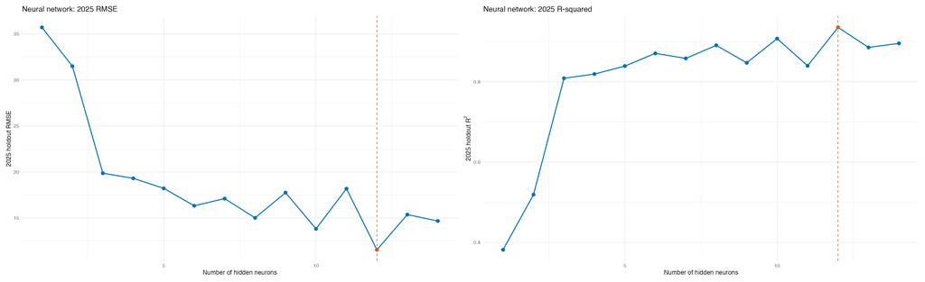

```r
nn_metrics_plot <- plot_nn_metrics(
  nn_results
)

# Save and display
nn_metrics_path <- file.path(
  figure_output_dir,
  "nn_grid_metrics.png"
)
ggsave(
  nn_metrics_path,
  nn_metrics_plot,
  width = 22.5,
  height = 6.875,
  dpi = 160
)

knitr::include_graphics(nn_metrics_path)
```

### Residual Diagnostics

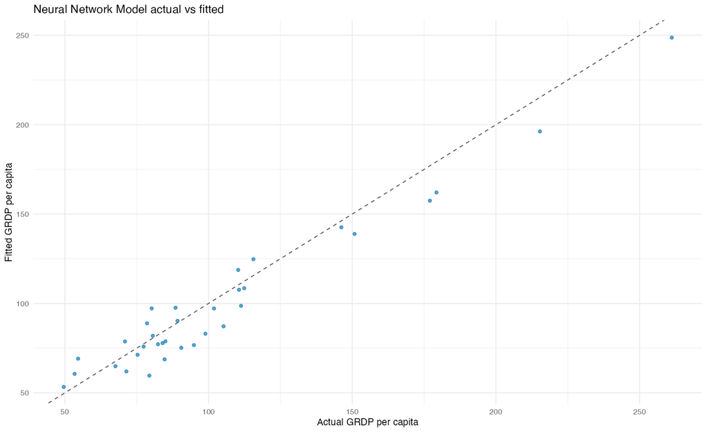

```r
# Plot holdout actual vs fitted.
holdout_actual_fitted_plot <- plot_actual_vs_fitted(
  holdout_data,
  holdout_predictions[, selected_index],
  "Neural Network Model"
)

# Save and display
holdout_actual_fitted_path <- file.path(
  figure_output_dir,
  "nn_model_holdout_actual_vs_fitted.png"
)
ggsave(
  holdout_actual_fitted_path,
  holdout_actual_fitted_plot,
  width = 11.25,
  height = 6.875,
  dpi = 160
)

knitr::include_graphics(holdout_actual_fitted_path)
```

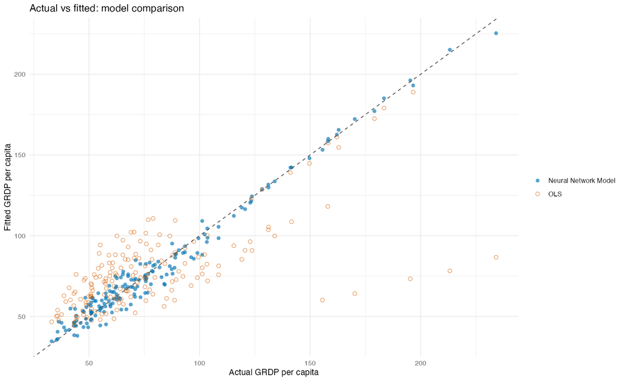

```r
training_model_comparison_plot <- plot_model_comparison(
  training_data,
  training_predictions[, selected_index],
  ols_training_predictions,
  "Neural Network Model",
  "OLS"
)

# Save and display
training_comparison_path <- file.path(
  figure_output_dir,
  "nn_model_training_actual_vs_fitted_comparison.png"
)
ggsave(
  training_comparison_path,
  training_model_comparison_plot,
  width = 11.25,
  height = 6.875,
  dpi = 160
)

knitr::include_graphics(training_comparison_path)
```

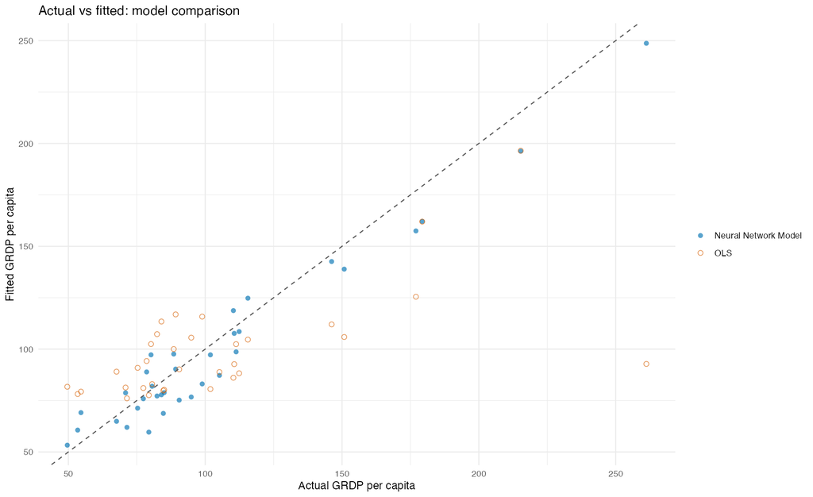

```r
holdout_model_comparison_plot <- plot_model_comparison(
  holdout_data,
  holdout_predictions[, selected_index],
  ols_holdout_predictions,
  "Neural Network Model",
  "OLS"
)

# Save and display
holdout_comparison_path <- file.path(
  figure_output_dir,
  "nn_model_holdout_actual_vs_fitted_comparison.png"
)
ggsave(
  holdout_comparison_path,
  holdout_model_comparison_plot,
  width = 11.25,
  height = 6.875,
  dpi = 160
)

knitr::include_graphics(holdout_comparison_path)
```

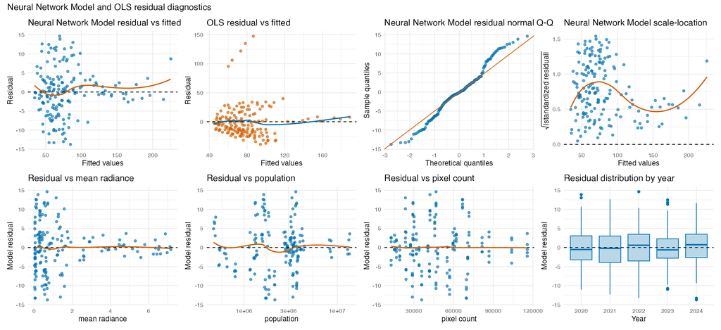

```r
# Plot training diagnostic plots.
training_plots <- plot_residual_diagnostics(
  opt_training_diagnostics$diagnostics,
  "Neural Network Model",
  "OLS"
)

# Save and display
training_diagnostics_path <- file.path(
  figure_output_dir,
  "nn_model_training_residual_diagnostics.png"
)
ggsave(
  training_diagnostics_path,
  training_plots$combined,
  width = 15,
  height = 6.875,
  dpi = 160
)

knitr::include_graphics(training_diagnostics_path)
```

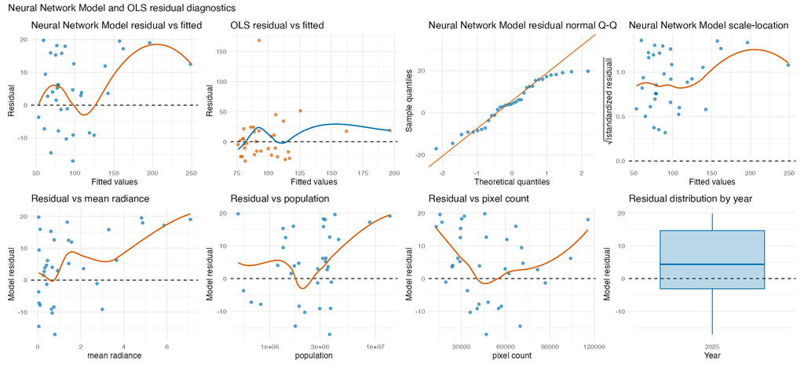

```r
# Plot holdout diagnostic plots.
holdout_plots <- plot_residual_diagnostics(
  opt_holdout_diagnostics$diagnostics,
  "Neural Network Model",
  "OLS"
)

# Save and display
holdout_diagnostics_path <- file.path(
  figure_output_dir,
  "nn_model_holdout_residual_diagnostics.png"
)
ggsave(
  holdout_diagnostics_path,
  holdout_plots$combined,
  width = 15,
  height = 6.875,
  dpi = 160
)

knitr::include_graphics(holdout_diagnostics_path)
```

### Training using all data

Prepare the complete dataset for the full optimization model. All observations are used to standardize the predictor variables and response variable.

```r
full_model_data <- prepare_full_model_setup(regression_data)
X <- full_model_data$X
y <- full_model_data$y
years <- full_model_data$years

regression_sf <- full_model_data$regression_sf
feature_columns <- full_model_data$feature_columns
feature_means <- full_model_data$feature_means
feature_sds <- full_model_data$feature_sds
response_mean <- full_model_data$response_mean
response_sd <- full_model_data$response_sd
```

Fit the Neural Network model using all available years.

```r
fitted_model <- local({
  variable_names <- colnames(X)
  training_years <- years
  training_data <- regression_sf

  list(
  model = fit_neural_network(
    x = X,
    y = y,
    size = selected_size,
    decay = selected_decay,
    seed = 401
  ),
    variable_names = variable_names,
    years = training_years,
    feature_columns = feature_columns,
    feature_means = feature_means,
    feature_sds = feature_sds,
    response_mean = response_mean,
    response_sd = response_sd,

  make_prediction = function(newdata) {
    # Calculate temporal extrapolation weights.
      T <- length(training_years)
      time_index <- seq_len(T)
      time_mean <- mean(time_index)

      target_index <- newdata$year - min(training_years) + 1

      temporal_weights <- sapply(target_index, function(t_star) {
        1 / T +
          (t_star - time_mean) *
          (time_index - time_mean) /
          sum((time_index - time_mean)^2)
      })

      # Standardize prediction features.
      scaled_features <- as.matrix(newdata[feature_columns])

      scaled_features <- sweep(
        scaled_features, 2,
        feature_means[feature_columns], "-"
      )

      scaled_features <- sweep(
        scaled_features, 2,
        feature_sds[feature_columns], "/"
      )

      # Construct prediction matrix.
      prediction_X <- cbind(
        t(temporal_weights),
        scaled_features
      )

      colnames(prediction_X) <- variable_names

    prediction <- as.vector(predict(model, newdata = prediction_X)) * response_sd +
    response_mean

    return (prediction)
}
)
})

model_path = file.path(model_output_dir, "nn_model.rds")
saveRDS(fitted_model, model_path)
```

### 2025 Level-2 Predictions

Using the trained model from the previous section, we first predicts GRDP per capita for each level-2 unit using the 2025 intercept and the same means and standard deviations used to standardize the training data.

```r
# Setting up prediction data
level2_prediction_data <- prepare_prediction_data(
  prediction_data = prediction_data,
  provincial_grdp_data = provincial_grdp_data,
  provincial_population_data = provincial_population_data,
  feature_columns = feature_columns,
  feature_means = feature_means,
  feature_sds = feature_sds
)
```

The raw prediction is
$$\hat{y}_{i,2025}^{\text{NN}}
=
f_{\text{NN}}\left(\mathbf{X}_{i,2025}\right)$$

```r
# Make raw prediction
raw_predictions <- fitted_model$make_prediction(level2_prediction_data)
level2_prediction_data$raw_predictions <- raw_predictions
```

Next, we adjust these predictions so that their population weighted total matches the province’s reported 2025 GRDP per capita multiplied by its total population.

#### Adjustment Solution 1: Additive adjustment

To do this, we add the same adjustment $\delta_j$ to every level-2 prediction within province $j$:

$$\tilde y_{ij} = \hat y_{ij} + \delta_j$$

The adjustment is calculated as:

$$\delta_j = \frac{g_j\sum_{i\in
j}P_{ij}-\sum_{i\in j}P_{ij}\hat y_{ij}} {\sum_{i\in j}P_{ij}}$$

where $g_j$ is the province’s reported GRDP per capita and $P_{ij}$ is the population of level-2 unit $i$.

```r
# Adjustment Solution 1: Additive adjustment
calculate_additive_adjustments <- function(level2_prediction_data) {

  province_groups <- split(
    seq_len(nrow(level2_prediction_data)),
    level2_prediction_data$level_1
  )

  vapply(province_groups, function(idx) {

    population <- level2_prediction_data$population[idx]

    level2_prediction_data$grdp_pc_2025[idx[1]] -
      weighted.mean(
        level2_prediction_data$raw_predictions[idx],
        population
      )

  }, numeric(1))
}

# Apply additive adjustment
additive_adjustments <- calculate_additive_adjustments(
  level2_prediction_data
)

level2_prediction_data$additive_adjustment <-
  unname(additive_adjustments[level2_prediction_data$level_1])

level2_prediction_data$additive_predictions <-
  level2_prediction_data$raw_predictions +
  level2_prediction_data$additive_adjustment
```

#### Adjustment Solution 2: Proportional scaling

Another approach is to adjust the level-2 predictions by multiplying every prediction within province $j$ by a common scaling factor:

$$s_j = \frac{g_j}{\bar{y}_j},$$

where

$$\bar{y}_j = \frac{\sum_{i=1}^{n_j}
P_{ij}\hat{y}_{ij}} {\sum_{i=1}^{n_j} P_{ij}}$$

is the population-weighted average of the raw level-2 predictions in province $j$. The adjusted prediction for each level-2 unit is then:

$$\tilde {y}_{ij}=s_j\hat{y}_{ij}.$$

```r
# Adjustment Solution 2: Proportional scaling
calculate_scaling_adjustments <- function(level2_prediction_data) {
  province_groups <- split(
    seq_len(nrow(level2_prediction_data)),
    level2_prediction_data$level_1
  )

  vapply(province_groups, function(idx) {

    population <- level2_prediction_data$population[idx]

    predicted_mean <- weighted.mean(
      level2_prediction_data$raw_predictions[idx],
      population
    )

    level2_prediction_data$grdp_pc_2025[idx[1]] /
      predicted_mean

  }, numeric(1))
}

# Apply proportional scaling
scaling_adjustments <- calculate_scaling_adjustments(level2_prediction_data)

level2_prediction_data$scaling_adjustments <-
  unname(scaling_adjustments[level2_prediction_data$level_1])

level2_prediction_data$scaled_predictions <-
  level2_prediction_data$raw_predictions *
  level2_prediction_data$scaling_adjustments
```

```r
# Save prediction results
prediction_output <- file.path(
  data_output_dir,
  "gw_model_level2_predictions.csv"
)

write.csv(
  level2_prediction_data,
  prediction_output,
  row.names = FALSE
)
```